# Risk Factor Analysis

## Outcome Variable

**Outcome Variable:** whz

## Predictor Variables

**Intervention Variable:** enstunt

**Adjustment Set:**

- arm
- sex
- W_mage
- meducyrs
- feducyrs
- vagbrth
- single
- brthmon
- W_parity
- impsan
- delta_W_mage
- delta_meducyrs
- delta_feducyrs
- delta_vagbrth
- delta_single
- delta_brthmon
- delta_W_parity
- delta_impsan

## Stratifying Variables

The analysis was stratified on these variable(s):

- agecat
- studyid
- country

## Data Summary

| agecat | studyid | country | enstunt | n_cell | n |
| --- | --- | --- | --- | --- | --- |
| Birth | ki0047075b-MAL-ED | BANGLADESH | 0 | 187 | 215 |
| Birth | ki0047075b-MAL-ED | BANGLADESH | 1 | 28 | 215 |
| Birth | ki0047075b-MAL-ED | BRAZIL | 0 | 56 | 62 |
| Birth | ki0047075b-MAL-ED | BRAZIL | 1 | 6 | 62 |
| Birth | ki0047075b-MAL-ED | INDIA | 0 | 37 | 45 |
| Birth | ki0047075b-MAL-ED | INDIA | 1 | 8 | 45 |
| Birth | ki0047075b-MAL-ED | NEPAL | 0 | 25 | 26 |
| Birth | ki0047075b-MAL-ED | NEPAL | 1 | 1 | 26 |
| Birth | ki0047075b-MAL-ED | PERU | 0 | 207 | 228 |
| Birth | ki0047075b-MAL-ED | PERU | 1 | 21 | 228 |
| Birth | ki0047075b-MAL-ED | SOUTH AFRICA | 0 | 112 | 120 |
| Birth | ki0047075b-MAL-ED | SOUTH AFRICA | 1 | 8 | 120 |
| Birth | ki0047075b-MAL-ED | TANZANIA, UNITED REPUBLIC OF | 0 | 102 | 115 |
| Birth | ki0047075b-MAL-ED | TANZANIA, UNITED REPUBLIC OF | 1 | 13 | 115 |
| Birth | ki1000108-CMC-V-BCS-2002 | INDIA | 0 | 74 | 86 |
| Birth | ki1000108-CMC-V-BCS-2002 | INDIA | 1 | 12 | 86 |
| Birth | ki1000108-IRC | INDIA | 0 | 318 | 343 |
| Birth | ki1000108-IRC | INDIA | 1 | 25 | 343 |
| Birth | ki1000109-EE | PAKISTAN | 0 | 137 | 177 |
| Birth | ki1000109-EE | PAKISTAN | 1 | 40 | 177 |
| Birth | ki1000109-ResPak | PAKISTAN | 0 | 28 | 38 |
| Birth | ki1000109-ResPak | PAKISTAN | 1 | 10 | 38 |
| Birth | ki1000304b-SAS-CompFeed | INDIA | 0 | 901 | 1103 |
| Birth | ki1000304b-SAS-CompFeed | INDIA | 1 | 202 | 1103 |
| Birth | ki1017093-NIH-Birth | BANGLADESH | 0 | 506 | 575 |
| Birth | ki1017093-NIH-Birth | BANGLADESH | 1 | 69 | 575 |
| Birth | ki1017093b-PROVIDE | BANGLADESH | 0 | 491 | 532 |
| Birth | ki1017093b-PROVIDE | BANGLADESH | 1 | 41 | 532 |
| Birth | ki1017093c-NIH-Crypto | BANGLADESH | 0 | 625 | 707 |
| Birth | ki1017093c-NIH-Crypto | BANGLADESH | 1 | 82 | 707 |

[output cut: 134 more lines]

The following strata were considered:

- agecat: 24 months, studyid: ki0047075b-MAL-ED, country: BANGLADESH
- agecat: 24 months, studyid: ki0047075b-MAL-ED, country: BRAZIL
- agecat: 24 months, studyid: ki0047075b-MAL-ED, country: INDIA
- agecat: 24 months, studyid: ki0047075b-MAL-ED, country: NEPAL
- agecat: 24 months, studyid: ki0047075b-MAL-ED, country: PERU
- agecat: 24 months, studyid: ki0047075b-MAL-ED, country: SOUTH AFRICA
- agecat: 24 months, studyid: ki0047075b-MAL-ED, country: TANZANIA, UNITED REPUBLIC OF
- agecat: 24 months, studyid: ki1000108-CMC-V-BCS-2002, country: INDIA
- agecat: 24 months, studyid: ki1000108-IRC, country: INDIA
- agecat: 24 months, studyid: ki1000109-EE, country: PAKISTAN
- agecat: 24 months, studyid: ki1017093-NIH-Birth, country: BANGLADESH
- agecat: 24 months, studyid: ki1017093b-PROVIDE, country: BANGLADESH
- agecat: 24 months, studyid: ki1017093c-NIH-Crypto, country: BANGLADESH
- agecat: 24 months, studyid: ki1066203-TanzaniaChild2, country: TANZANIA, UNITED REPUBLIC OF
- agecat: 24 months, studyid: ki1101329-Keneba, country: GAMBIA
- agecat: 24 months, studyid: ki1113344-GMS-Nepal, country: NEPAL
- agecat: 24 months, studyid: ki1114097-CMIN, country: BANGLADESH
- agecat: 24 months, studyid: ki1114097-CONTENT, country: PERU
- agecat: 24 months, studyid: ki1119695-PROBIT, country: BELARUS
- agecat: 24 months, studyid: ki1126311-ZVITAMBO, country: ZIMBABWE
- agecat: 24 months, studyid: ki1135781-COHORTS, country: GUATEMALA
- agecat: 24 months, studyid: ki1135781-COHORTS, country: INDIA
- agecat: 24 months, studyid: ki1135781-COHORTS, country: PHILIPPINES
- agecat: 24 months, studyid: ki1148112-LCNI-5, country: MALAWI
- agecat: 24 months, studyid: kiGH5241-JiVitA-3, country: BANGLADESH
- agecat: 24 months, studyid: kiGH5241-JiVitA-4, country: BANGLADESH
- agecat: 6 months, studyid: ki0047075b-MAL-ED, country: BANGLADESH
- agecat: 6 months, studyid: ki0047075b-MAL-ED, country: BRAZIL
- agecat: 6 months, studyid: ki0047075b-MAL-ED, country: INDIA
- agecat: 6 months, studyid: ki0047075b-MAL-ED, country: NEPAL
- agecat: 6 months, studyid: ki0047075b-MAL-ED, country: PERU
- agecat: 6 months, studyid: ki0047075b-MAL-ED, country: SOUTH AFRICA
- agecat: 6 months, studyid: ki0047075b-MAL-ED, country: TANZANIA, UNITED REPUBLIC OF
- agecat: 6 months, studyid: ki1000108-CMC-V-BCS-2002, country: INDIA
- agecat: 6 months, studyid: ki1000108-IRC, country: INDIA
- agecat: 6 months, studyid: ki1000109-EE, country: PAKISTAN
- agecat: 6 months, studyid: ki1000109-ResPak, country: PAKISTAN
- agecat: 6 months, studyid: ki1000304b-SAS-CompFeed, country: INDIA
- agecat: 6 months, studyid: ki1000304b-SAS-FoodSuppl, country: INDIA
- agecat: 6 months, studyid: ki1017093-NIH-Birth, country: BANGLADESH
- agecat: 6 months, studyid: ki1017093b-PROVIDE, country: BANGLADESH
- agecat: 6 months, studyid: ki1017093c-NIH-Crypto, country: BANGLADESH
- agecat: 6 months, studyid: ki1066203-TanzaniaChild2, country: TANZANIA, UNITED REPUBLIC OF
- agecat: 6 months, studyid: ki1101329-Keneba, country: GAMBIA
- agecat: 6 months, studyid: ki1112895-Guatemala BSC, country: GUATEMALA
- agecat: 6 months, studyid: ki1113344-GMS-Nepal, country: NEPAL
- agecat: 6 months, studyid: ki1114097-CMIN, country: BANGLADESH
- agecat: 6 months, studyid: ki1114097-CONTENT, country: PERU
- agecat: 6 months, studyid: ki1119695-PROBIT, country: BELARUS
- agecat: 6 months, studyid: ki1126311-ZVITAMBO, country: ZIMBABWE
- agecat: 6 months, studyid: ki1135781-COHORTS, country: GUATEMALA
- agecat: 6 months, studyid: ki1135781-COHORTS, country: INDIA
- agecat: 6 months, studyid: ki1135781-COHORTS, country: PHILIPPINES
- agecat: 6 months, studyid: ki1148112-LCNI-5, country: MALAWI
- agecat: 6 months, studyid: kiGH5241-JiVitA-3, country: BANGLADESH
- agecat: 6 months, studyid: kiGH5241-JiVitA-4, country: BANGLADESH
- agecat: Birth, studyid: ki0047075b-MAL-ED, country: BANGLADESH
- agecat: Birth, studyid: ki0047075b-MAL-ED, country: BRAZIL
- agecat: Birth, studyid: ki0047075b-MAL-ED, country: INDIA
- agecat: Birth, studyid: ki0047075b-MAL-ED, country: NEPAL
- agecat: Birth, studyid: ki0047075b-MAL-ED, country: PERU
- agecat: Birth, studyid: ki0047075b-MAL-ED, country: SOUTH AFRICA
- agecat: Birth, studyid: ki0047075b-MAL-ED, country: TANZANIA, UNITED REPUBLIC OF
- agecat: Birth, studyid: ki1000108-CMC-V-BCS-2002, country: INDIA
- agecat: Birth, studyid: ki1000108-IRC, country: INDIA
- agecat: Birth, studyid: ki1000109-EE, country: PAKISTAN
- agecat: Birth, studyid: ki1000109-ResPak, country: PAKISTAN
- agecat: Birth, studyid: ki1000304b-SAS-CompFeed, country: INDIA
- agecat: Birth, studyid: ki1017093-NIH-Birth, country: BANGLADESH
- agecat: Birth, studyid: ki1017093b-PROVIDE, country: BANGLADESH
- agecat: Birth, studyid: ki1017093c-NIH-Crypto, country: BANGLADESH
- agecat: Birth, studyid: ki1101329-Keneba, country: GAMBIA
- agecat: Birth, studyid: ki1113344-GMS-Nepal, country: NEPAL
- agecat: Birth, studyid: ki1114097-CMIN, country: BANGLADESH
- agecat: Birth, studyid: ki1114097-CONTENT, country: PERU
- agecat: Birth, studyid: ki1119695-PROBIT, country: BELARUS
- agecat: Birth, studyid: ki1126311-ZVITAMBO, country: ZIMBABWE
- agecat: Birth, studyid: ki1135781-COHORTS, country: GUATEMALA
- agecat: Birth, studyid: ki1135781-COHORTS, country: INDIA
- agecat: Birth, studyid: ki1135781-COHORTS, country: PHILIPPINES
- agecat: Birth, studyid: kiGH5241-JiVitA-3, country: BANGLADESH
- agecat: Birth, studyid: kiGH5241-JiVitA-4, country: BANGLADESH

### Dropped Strata

Some strata were dropped due to rare outcomes:

- agecat: Birth, studyid: ki0047075b-MAL-ED, country: NEPAL
- agecat: Birth, studyid: ki1101329-Keneba, country: GAMBIA
- agecat: Birth, studyid: ki1114097-CMIN, country: BANGLADESH
- agecat: Birth, studyid: ki1114097-CONTENT, country: PERU
- agecat: 24 months, studyid: ki1066203-TanzaniaChild2, country: TANZANIA, UNITED REPUBLIC OF

## Methods Detail

We’re interested in the causal parameters $E[Y_a]$ for all values of $a \in \mathcal{A}$. These parameters represent the mean outcome if, possibly contrary to fact, we intervened to set all units to have $A=a$. Under the randomization and positivity assumptions, these are identified by the statistical parameters $\psi_a=E_W[E_{Y|A,W}(Y|A=a,W)]$. In addition, we’re interested in the mean of $Y$, $E[Y]$ under no intervention (the observed mean). We will estimate these parameters by using SuperLearner to fit the relevant likelihood factors – $E_{Y|A,W}(Y|A=a,W)$ and $p(A=a|W)$, and then updating our likelihood fit using a joint TMLE.

For unadjusted analyses ($W=\{\}$), initial likelihoods were estimated using Lrnr_glm to estimate the simple $E(Y|A)$ and Lrnr_mean to estimate $p(A)$. For adjusted analyses, a small library containing Lrnr_glmnet, Lrnr_xgboost, and Lrnr_mean was used.

Having estimated these parameters, we will then use the delta method to estimate relative risks and attributable risks relative to a prespecified baseline level of $A$.

# Results Detail

## Results Plots

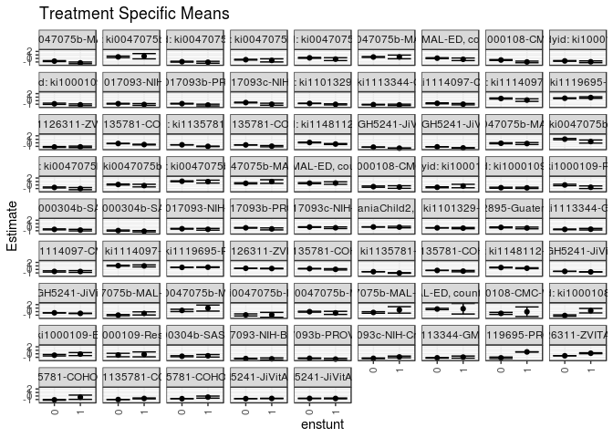

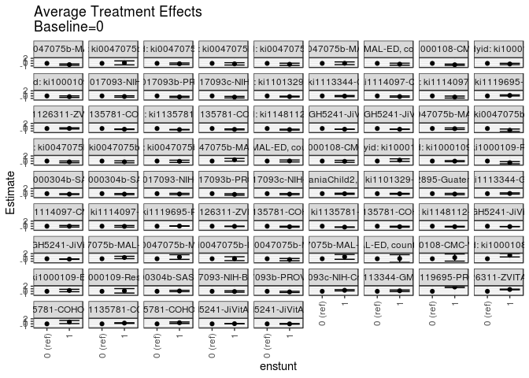

[figure not shown]

## Results Table

### Parameter: TSM

| agecat | studyid | country | intervention_level | baseline_level | estimate | ci_lower | ci_upper |
| --- | --- | --- | --- | --- | --- | --- | --- |
| Birth | ki0047075b-MAL-ED | BANGLADESH | 0 | NA | -1.0000109 | -1.1524118 | -0.8476101 |
| Birth | ki0047075b-MAL-ED | BANGLADESH | 1 | NA | -0.5141803 | -0.9620065 | -0.0663541 |
| Birth | ki0047075b-MAL-ED | BRAZIL | 0 | NA | 0.3380357 | 0.0083857 | 0.6676857 |
| Birth | ki0047075b-MAL-ED | BRAZIL | 1 | NA | 1.0083333 | 0.1448999 | 1.8717667 |
| Birth | ki0047075b-MAL-ED | INDIA | 0 | NA | -0.9356757 | -1.2327587 | -0.6385926 |
| Birth | ki0047075b-MAL-ED | INDIA | 1 | NA | -0.9175000 | -1.6199423 | -0.2150577 |
| Birth | ki0047075b-MAL-ED | PERU | 0 | NA | -0.0208665 | -0.1458799 | 0.1041468 |
| Birth | ki0047075b-MAL-ED | PERU | 1 | NA | -0.3639505 | -0.8038366 | 0.0759356 |
| Birth | ki0047075b-MAL-ED | SOUTH AFRICA | 0 | NA | -0.2412500 | -0.4566344 | -0.0258656 |
| Birth | ki0047075b-MAL-ED | SOUTH AFRICA | 1 | NA | 0.4887500 | -0.4348184 | 1.4123184 |
| Birth | ki0047075b-MAL-ED | TANZANIA, UNITED REPUBLIC OF | 0 | NA | 0.7419345 | 0.5495166 | 0.9343524 |
| Birth | ki0047075b-MAL-ED | TANZANIA, UNITED REPUBLIC OF | 1 | NA | 0.8227519 | -0.6837591 | 2.3292629 |
| Birth | ki1000108-CMC-V-BCS-2002 | INDIA | 0 | NA | -0.5005036 | -0.7882008 | -0.2128065 |
| Birth | ki1000108-CMC-V-BCS-2002 | INDIA | 1 | NA | -0.0404174 | -1.4074635 | 1.3266286 |
| Birth | ki1000108-IRC | INDIA | 0 | NA | -1.1096812 | -1.3008982 | -0.9184642 |
| Birth | ki1000108-IRC | INDIA | 1 | NA | 0.2613062 | -0.3860050 | 0.9086174 |
| Birth | ki1000109-EE | PAKISTAN | 0 | NA | -0.3939402 | -0.6025402 | -0.1853403 |
| Birth | ki1000109-EE | PAKISTAN | 1 | NA | -0.0784329 | -0.5075749 | 0.3507091 |
| Birth | ki1000109-ResPak | PAKISTAN | 0 | NA | -0.3457294 | -0.8346675 | 0.1432088 |
| Birth | ki1000109-ResPak | PAKISTAN | 1 | NA | -0.1644664 | -0.8662384 | 0.5373056 |
| Birth | ki1000304b-SAS-CompFeed | INDIA | 0 | NA | -0.6916348 | -0.8421737 | -0.5410959 |
| Birth | ki1000304b-SAS-CompFeed | INDIA | 1 | NA | -0.5654183 | -0.9273312 | -0.2035054 |
| Birth | ki1017093-NIH-Birth | BANGLADESH | 0 | NA | -1.3487127 | -1.4486900 | -1.2487354 |
| Birth | ki1017093-NIH-Birth | BANGLADESH | 1 | NA | -1.4293524 | -1.7067868 | -1.1519179 |
| Birth | ki1017093b-PROVIDE | BANGLADESH | 0 | NA | -1.2756879 | -1.3563976 | -1.1949783 |
| Birth | ki1017093b-PROVIDE | BANGLADESH | 1 | NA | -1.5104057 | -1.7403953 | -1.2804161 |
| Birth | ki1017093c-NIH-Crypto | BANGLADESH | 0 | NA | -1.2841370 | -1.3734983 | -1.1947758 |
| Birth | ki1017093c-NIH-Crypto | BANGLADESH | 1 | NA | -0.8844464 | -1.1158610 | -0.6530318 |
| Birth | ki1113344-GMS-Nepal | NEPAL | 0 | NA | -1.1400360 | -1.2321383 | -1.0479337 |
| Birth | ki1113344-GMS-Nepal | NEPAL | 1 | NA | -0.9400489 | -1.2388295 | -0.6412684 |

[output cut: 124 more lines]

### Parameter: E(Y)

| agecat | studyid | country | intervention_level | baseline_level | estimate | ci_lower | ci_upper |
| --- | --- | --- | --- | --- | --- | --- | --- |
| Birth | ki0047075b-MAL-ED | BANGLADESH | NA | NA | -0.9412093 | -1.0864308 | -0.7959878 |
| Birth | ki0047075b-MAL-ED | BRAZIL | NA | NA | 0.4029032 | 0.0896793 | 0.7161272 |
| Birth | ki0047075b-MAL-ED | INDIA | NA | NA | -0.9324444 | -1.2067907 | -0.6580982 |
| Birth | ki0047075b-MAL-ED | PERU | NA | NA | -0.0520175 | -0.1725298 | 0.0684947 |
| Birth | ki0047075b-MAL-ED | SOUTH AFRICA | NA | NA | -0.1925833 | -0.4053570 | 0.0201904 |
| Birth | ki0047075b-MAL-ED | TANZANIA, UNITED REPUBLIC OF | NA | NA | 0.7624348 | 0.5710709 | 0.9537986 |
| Birth | ki1000108-CMC-V-BCS-2002 | INDIA | NA | NA | -0.4648256 | -0.7643210 | -0.1653302 |
| Birth | ki1000108-IRC | INDIA | NA | NA | -1.0105831 | -1.1973019 | -0.8238643 |
| Birth | ki1000109-EE | PAKISTAN | NA | NA | -0.3333051 | -0.5209779 | -0.1456323 |
| Birth | ki1000109-ResPak | PAKISTAN | NA | NA | -0.3663158 | -0.7677415 | 0.0351099 |
| Birth | ki1000304b-SAS-CompFeed | INDIA | NA | NA | -0.6700453 | -0.8474950 | -0.4925957 |
| Birth | ki1017093-NIH-Birth | BANGLADESH | NA | NA | -1.3499217 | -1.4444634 | -1.2553801 |
| Birth | ki1017093b-PROVIDE | BANGLADESH | NA | NA | -1.2984586 | -1.3752758 | -1.2216415 |
| Birth | ki1017093c-NIH-Crypto | BANGLADESH | NA | NA | -1.2441513 | -1.3281130 | -1.1601897 |
| Birth | ki1113344-GMS-Nepal | NEPAL | NA | NA | -1.1164431 | -1.2040134 | -1.0288728 |
| Birth | ki1119695-PROBIT | BELARUS | NA | NA | -1.1448633 | -1.3544229 | -0.9353037 |
| Birth | ki1126311-ZVITAMBO | ZIMBABWE | NA | NA | -0.5154897 | -0.5413479 | -0.4896314 |
| Birth | ki1135781-COHORTS | GUATEMALA | NA | NA | -1.0621429 | -1.1631387 | -0.9611471 |
| Birth | ki1135781-COHORTS | INDIA | NA | NA | -0.9847457 | -1.0145305 | -0.9549609 |
| Birth | ki1135781-COHORTS | PHILIPPINES | NA | NA | -0.7427251 | -0.7890855 | -0.6963647 |
| Birth | kiGH5241-JiVitA-3 | BANGLADESH | NA | NA | -0.7501567 | -0.7680049 | -0.7323085 |
| Birth | kiGH5241-JiVitA-4 | BANGLADESH | NA | NA | -0.6886269 | -0.7410452 | -0.6362086 |
| 6 months | ki0047075b-MAL-ED | BANGLADESH | NA | NA | -0.1383956 | -0.2672708 | -0.0095204 |
| 6 months | ki0047075b-MAL-ED | BRAZIL | NA | NA | 0.9717225 | 0.8073791 | 1.1360658 |
| 6 months | ki0047075b-MAL-ED | INDIA | NA | NA | -0.7082698 | -0.8347304 | -0.5818092 |
| 6 months | ki0047075b-MAL-ED | NEPAL | NA | NA | 0.1110452 | -0.0202712 | 0.2423616 |
| 6 months | ki0047075b-MAL-ED | PERU | NA | NA | 1.0568987 | 0.9352990 | 1.1784983 |
| 6 months | ki0047075b-MAL-ED | SOUTH AFRICA | NA | NA | 0.5427231 | 0.3906363 | 0.6948099 |
| 6 months | ki0047075b-MAL-ED | TANZANIA, UNITED REPUBLIC OF | NA | NA | 0.5362213 | 0.4049390 | 0.6675036 |
| 6 months | ki1000108-CMC-V-BCS-2002 | INDIA | NA | NA | -0.5026766 | -0.6536848 | -0.3516685 |
| 6 months | ki1000108-IRC | INDIA | NA | NA | -0.5989297 | -0.7344491 | -0.4634104 |
| 6 months | ki1000109-EE | PAKISTAN | NA | NA | -0.7747022 | -0.8887874 | -0.6606170 |
| 6 months | ki1000109-ResPak | PAKISTAN | NA | NA | -0.1641841 | -0.3464247 | 0.0180565 |
| 6 months | ki1000304b-SAS-CompFeed | INDIA | NA | NA | -0.6657084 | -0.8024377 | -0.5289791 |
| 6 months | ki1000304b-SAS-FoodSuppl | INDIA | NA | NA | -1.0121579 | -1.1280429 | -0.8962729 |
| 6 months | ki1017093-NIH-Birth | BANGLADESH | NA | NA | -0.4474038 | -0.5378167 | -0.3569909 |
| 6 months | ki1017093b-PROVIDE | BANGLADESH | NA | NA | -0.1990907 | -0.2817968 | -0.1163845 |
| 6 months | ki1017093c-NIH-Crypto | BANGLADESH | NA | NA | 0.0297622 | -0.0491685 | 0.1086930 |
| 6 months | ki1066203-TanzaniaChild2 | TANZANIA, UNITED REPUBLIC OF | NA | NA | 0.0809332 | 0.0282644 | 0.1336020 |
| 6 months | ki1101329-Keneba | GAMBIA | NA | NA | -0.1846038 | -0.2354782 | -0.1337293 |
| 6 months | ki1112895-Guatemala BSC | GUATEMALA | NA | NA | -0.0840134 | -0.1945572 | 0.0265305 |
| 6 months | ki1113344-GMS-Nepal | NEPAL | NA | NA | -0.6038416 | -0.6899448 | -0.5177384 |
| 6 months | ki1114097-CMIN | BANGLADESH | NA | NA | -0.5780453 | -0.7226627 | -0.4334279 |
| 6 months | ki1114097-CONTENT | PERU | NA | NA | 1.0684318 | 0.9515274 | 1.1853362 |
| 6 months | ki1119695-PROBIT | BELARUS | NA | NA | 0.5792439 | 0.5193388 | 0.6391490 |
| 6 months | ki1126311-ZVITAMBO | ZIMBABWE | NA | NA | 0.3105514 | 0.2848767 | 0.3362262 |
| 6 months | ki1135781-COHORTS | GUATEMALA | NA | NA | 0.1940810 | 0.1226351 | 0.2655269 |
| 6 months | ki1135781-COHORTS | INDIA | NA | NA | -0.6908803 | -0.7184601 | -0.6633005 |
| 6 months | ki1135781-COHORTS | PHILIPPINES | NA | NA | -0.2938433 | -0.3352064 | -0.2524802 |
| 6 months | ki1148112-LCNI-5 | MALAWI | NA | NA | 0.4499404 | 0.3788501 | 0.5210308 |
| 6 months | kiGH5241-JiVitA-3 | BANGLADESH | NA | NA | -0.5930207 | -0.6125866 | -0.5734549 |
| 6 months | kiGH5241-JiVitA-4 | BANGLADESH | NA | NA | -0.3898055 | -0.4270507 | -0.3525603 |
| 24 months | ki0047075b-MAL-ED | BANGLADESH | NA | NA | -0.8201887 | -0.9423967 | -0.6979806 |
| 24 months | ki0047075b-MAL-ED | BRAZIL | NA | NA | 0.4592308 | 0.2528453 | 0.6656163 |
| 24 months | ki0047075b-MAL-ED | INDIA | NA | NA | -0.9522907 | -1.0676596 | -0.8369219 |
| 24 months | ki0047075b-MAL-ED | NEPAL | NA | NA | -0.3764474 | -0.4898516 | -0.2630431 |
| 24 months | ki0047075b-MAL-ED | PERU | NA | NA | 0.1204478 | 0.0005049 | 0.2403906 |
| 24 months | ki0047075b-MAL-ED | SOUTH AFRICA | NA | NA | 0.4148529 | 0.2940577 | 0.5356481 |
| 24 months | ki0047075b-MAL-ED | TANZANIA, UNITED REPUBLIC OF | NA | NA | 0.0539486 | -0.0712465 | 0.1791437 |
| 24 months | ki1000108-CMC-V-BCS-2002 | INDIA | NA | NA | -0.5571505 | -0.6585247 | -0.4557763 |
| 24 months | ki1000108-IRC | INDIA | NA | NA | -0.7458150 | -0.8368180 | -0.6548120 |
| 24 months | ki1000109-EE | PAKISTAN | NA | NA | -1.0120238 | -1.1588493 | -0.8651984 |
| 24 months | ki1017093-NIH-Birth | BANGLADESH | NA | NA | -0.9115790 | -1.0095022 | -0.8136559 |
| 24 months | ki1017093b-PROVIDE | BANGLADESH | NA | NA | -0.8928670 | -0.9755153 | -0.8102187 |
| 24 months | ki1017093c-NIH-Crypto | BANGLADESH | NA | NA | -0.6103502 | -0.7050157 | -0.5156847 |
| 24 months | ki1101329-Keneba | GAMBIA | NA | NA | -0.8099290 | -0.8570608 | -0.7627972 |
| 24 months | ki1113344-GMS-Nepal | NEPAL | NA | NA | -1.1363107 | -1.2252817 | -1.0473398 |
| 24 months | ki1114097-CMIN | BANGLADESH | NA | NA | -0.8535391 | -0.9644236 | -0.7426546 |
| 24 months | ki1114097-CONTENT | PERU | NA | NA | 0.5668293 | 0.4302437 | 0.7034148 |
| 24 months | ki1119695-PROBIT | BELARUS | NA | NA | 0.6874295 | 0.5756922 | 0.7991668 |
| 24 months | ki1126311-ZVITAMBO | ZIMBABWE | NA | NA | -1.1825404 | -1.2814625 | -1.0836183 |
| 24 months | ki1135781-COHORTS | GUATEMALA | NA | NA | -0.2815804 | -0.3354498 | -0.2277110 |
| 24 months | ki1135781-COHORTS | INDIA | NA | NA | -0.6073238 | -0.6354743 | -0.5791732 |
| 24 months | ki1135781-COHORTS | PHILIPPINES | NA | NA | -0.6099592 | -0.6467541 | -0.5731643 |
| 24 months | ki1148112-LCNI-5 | MALAWI | NA | NA | -0.0477709 | -0.1296526 | 0.0341109 |
| 24 months | kiGH5241-JiVitA-3 | BANGLADESH | NA | NA | -1.2994214 | -1.3227674 | -1.2760754 |
| 24 months | kiGH5241-JiVitA-4 | BANGLADESH | NA | NA | -1.2231088 | -1.2549632 | -1.1912543 |

### Parameter: ATE

| agecat | studyid | country | intervention_level | baseline_level | estimate | ci_lower | ci_upper |
| --- | --- | --- | --- | --- | --- | --- | --- |
| Birth | ki0047075b-MAL-ED | BANGLADESH | 0 | 0 | 0.0000000 | 0.0000000 | 0.0000000 |
| Birth | ki0047075b-MAL-ED | BANGLADESH | 1 | 0 | 0.4858306 | 0.0125092 | 0.9591521 |
| Birth | ki0047075b-MAL-ED | BRAZIL | 0 | 0 | 0.0000000 | 0.0000000 | 0.0000000 |
| Birth | ki0047075b-MAL-ED | BRAZIL | 1 | 0 | 0.6702976 | -0.2539244 | 1.5945196 |
| Birth | ki0047075b-MAL-ED | INDIA | 0 | 0 | 0.0000000 | 0.0000000 | 0.0000000 |
| Birth | ki0047075b-MAL-ED | INDIA | 1 | 0 | 0.0181757 | -0.7445061 | 0.7808575 |
| Birth | ki0047075b-MAL-ED | PERU | 0 | 0 | 0.0000000 | 0.0000000 | 0.0000000 |
| Birth | ki0047075b-MAL-ED | PERU | 1 | 0 | -0.3430840 | -0.8000217 | 0.1138538 |
| Birth | ki0047075b-MAL-ED | SOUTH AFRICA | 0 | 0 | 0.0000000 | 0.0000000 | 0.0000000 |
| Birth | ki0047075b-MAL-ED | SOUTH AFRICA | 1 | 0 | 0.7300000 | -0.2183507 | 1.6783507 |
| Birth | ki0047075b-MAL-ED | TANZANIA, UNITED REPUBLIC OF | 0 | 0 | 0.0000000 | 0.0000000 | 0.0000000 |
| Birth | ki0047075b-MAL-ED | TANZANIA, UNITED REPUBLIC OF | 1 | 0 | 0.0808174 | -1.4415305 | 1.6031653 |
| Birth | ki1000108-CMC-V-BCS-2002 | INDIA | 0 | 0 | 0.0000000 | 0.0000000 | 0.0000000 |
| Birth | ki1000108-CMC-V-BCS-2002 | INDIA | 1 | 0 | 0.4600862 | -0.9391344 | 1.8593068 |
| Birth | ki1000108-IRC | INDIA | 0 | 0 | 0.0000000 | 0.0000000 | 0.0000000 |
| Birth | ki1000108-IRC | INDIA | 1 | 0 | 1.3709874 | 0.6958264 | 2.0461484 |
| Birth | ki1000109-EE | PAKISTAN | 0 | 0 | 0.0000000 | 0.0000000 | 0.0000000 |
| Birth | ki1000109-EE | PAKISTAN | 1 | 0 | 0.3155073 | -0.1642817 | 0.7952963 |
| Birth | ki1000109-ResPak | PAKISTAN | 0 | 0 | 0.0000000 | 0.0000000 | 0.0000000 |
| Birth | ki1000109-ResPak | PAKISTAN | 1 | 0 | 0.1812630 | -0.6925184 | 1.0550443 |
| Birth | ki1000304b-SAS-CompFeed | INDIA | 0 | 0 | 0.0000000 | 0.0000000 | 0.0000000 |
| Birth | ki1000304b-SAS-CompFeed | INDIA | 1 | 0 | 0.1262165 | -0.1446809 | 0.3971139 |
| Birth | ki1017093-NIH-Birth | BANGLADESH | 0 | 0 | 0.0000000 | 0.0000000 | 0.0000000 |
| Birth | ki1017093-NIH-Birth | BANGLADESH | 1 | 0 | -0.0806397 | -0.3749958 | 0.2137164 |
| Birth | ki1017093b-PROVIDE | BANGLADESH | 0 | 0 | 0.0000000 | 0.0000000 | 0.0000000 |
| Birth | ki1017093b-PROVIDE | BANGLADESH | 1 | 0 | -0.2347178 | -0.4785401 | 0.0091045 |
| Birth | ki1017093c-NIH-Crypto | BANGLADESH | 0 | 0 | 0.0000000 | 0.0000000 | 0.0000000 |
| Birth | ki1017093c-NIH-Crypto | BANGLADESH | 1 | 0 | 0.3996906 | 0.1516962 | 0.6476850 |
| Birth | ki1113344-GMS-Nepal | NEPAL | 0 | 0 | 0.0000000 | 0.0000000 | 0.0000000 |
| Birth | ki1113344-GMS-Nepal | NEPAL | 1 | 0 | 0.1999871 | -0.1123360 | 0.5123102 |

[output cut: 124 more lines]

### Parameter: PAR

| agecat | studyid | country | intervention_level | baseline_level | estimate | ci_lower | ci_upper |
| --- | --- | --- | --- | --- | --- | --- | --- |
| Birth | ki0047075b-MAL-ED | BANGLADESH | 0 | NA | 0.0588016 | -0.0045437 | 0.1221470 |
| Birth | ki0047075b-MAL-ED | BRAZIL | 0 | NA | 0.0648675 | -0.0374695 | 0.1672045 |
| Birth | ki0047075b-MAL-ED | INDIA | 0 | NA | 0.0032312 | -0.1323722 | 0.1388347 |
| Birth | ki0047075b-MAL-ED | PERU | 0 | NA | -0.0311510 | -0.0736155 | 0.0113135 |
| Birth | ki0047075b-MAL-ED | SOUTH AFRICA | 0 | NA | 0.0486667 | -0.0225203 | 0.1198536 |
| Birth | ki0047075b-MAL-ED | TANZANIA, UNITED REPUBLIC OF | 0 | NA | 0.0205003 | -0.0854768 | 0.1264774 |
| Birth | ki1000108-CMC-V-BCS-2002 | INDIA | 0 | NA | 0.0356781 | -0.1416596 | 0.2130158 |
| Birth | ki1000108-IRC | INDIA | 0 | NA | 0.0990981 | 0.0385678 | 0.1596284 |
| Birth | ki1000109-EE | PAKISTAN | 0 | NA | 0.0606352 | -0.0492995 | 0.1705698 |
| Birth | ki1000109-ResPak | PAKISTAN | 0 | NA | -0.0205864 | -0.3075022 | 0.2663294 |
| Birth | ki1000304b-SAS-CompFeed | INDIA | 0 | NA | 0.0215895 | -0.0290866 | 0.0722655 |
| Birth | ki1017093-NIH-Birth | BANGLADESH | 0 | NA | -0.0012090 | -0.0377401 | 0.0353220 |
| Birth | ki1017093b-PROVIDE | BANGLADESH | 0 | NA | -0.0227707 | -0.0429811 | -0.0025604 |
| Birth | ki1017093c-NIH-Crypto | BANGLADESH | 0 | NA | 0.0399857 | 0.0098944 | 0.0700770 |
| Birth | ki1113344-GMS-Nepal | NEPAL | 0 | NA | 0.0235929 | -0.0088748 | 0.0560607 |
| Birth | ki1119695-PROBIT | BELARUS | 0 | NA | 0.0032526 | -0.0018519 | 0.0083571 |
| Birth | ki1126311-ZVITAMBO | ZIMBABWE | 0 | NA | 0.0391567 | 0.0314161 | 0.0468974 |
| Birth | ki1135781-COHORTS | GUATEMALA | 0 | NA | 0.0245553 | 0.0040565 | 0.0450540 |
| Birth | ki1135781-COHORTS | INDIA | 0 | NA | 0.0173423 | 0.0087623 | 0.0259222 |
| Birth | ki1135781-COHORTS | PHILIPPINES | 0 | NA | 0.0153514 | 0.0059372 | 0.0247656 |
| Birth | kiGH5241-JiVitA-3 | BANGLADESH | 0 | NA | 0.0084600 | 0.0027822 | 0.0141378 |
| Birth | kiGH5241-JiVitA-4 | BANGLADESH | 0 | NA | -0.0017739 | -0.0258836 | 0.0223357 |
| 6 months | ki0047075b-MAL-ED | BANGLADESH | 0 | NA | -0.0189983 | -0.0700831 | 0.0320865 |
| 6 months | ki0047075b-MAL-ED | BRAZIL | 0 | NA | -0.0818758 | -0.1453677 | -0.0183838 |
| 6 months | ki0047075b-MAL-ED | INDIA | 0 | NA | -0.0207807 | -0.0760034 | 0.0344421 |
| 6 months | ki0047075b-MAL-ED | NEPAL | 0 | NA | -0.0367700 | -0.0850938 | 0.0115537 |
| 6 months | ki0047075b-MAL-ED | PERU | 0 | NA | -0.0149931 | -0.0670972 | 0.0371110 |
| 6 months | ki0047075b-MAL-ED | SOUTH AFRICA | 0 | NA | 0.0524123 | -0.0097900 | 0.1146147 |
| 6 months | ki0047075b-MAL-ED | TANZANIA, UNITED REPUBLIC OF | 0 | NA | 0.0039120 | -0.0546075 | 0.0624314 |
| 6 months | ki1000108-CMC-V-BCS-2002 | INDIA | 0 | NA | -0.0464984 | -0.1273253 | 0.0343286 |
| 6 months | ki1000108-IRC | INDIA | 0 | NA | 0.0397367 | -0.0256181 | 0.1050914 |
| 6 months | ki1000109-EE | PAKISTAN | 0 | NA | -0.0139224 | -0.1161596 | 0.0883148 |
| 6 months | ki1000109-ResPak | PAKISTAN | 0 | NA | -0.1836095 | -0.3063611 | -0.0608579 |
| 6 months | ki1000304b-SAS-CompFeed | INDIA | 0 | NA | -0.0574273 | -0.1025194 | -0.0123351 |
| 6 months | ki1000304b-SAS-FoodSuppl | INDIA | 0 | NA | -0.0643156 | -0.1570374 | 0.0284063 |
| 6 months | ki1017093-NIH-Birth | BANGLADESH | 0 | NA | -0.0146699 | -0.0577391 | 0.0283994 |
| 6 months | ki1017093b-PROVIDE | BANGLADESH | 0 | NA | -0.0309206 | -0.0608816 | -0.0009595 |
| 6 months | ki1017093c-NIH-Crypto | BANGLADESH | 0 | NA | -0.0240283 | -0.0592757 | 0.0112191 |
| 6 months | ki1066203-TanzaniaChild2 | TANZANIA, UNITED REPUBLIC OF | 0 | NA | -0.0007545 | -0.0154967 | 0.0139877 |
| 6 months | ki1101329-Keneba | GAMBIA | 0 | NA | -0.0072569 | -0.0244848 | 0.0099711 |
| 6 months | ki1112895-Guatemala BSC | GUATEMALA | 0 | NA | -0.0371778 | -0.1008211 | 0.0264655 |
| 6 months | ki1113344-GMS-Nepal | NEPAL | 0 | NA | 0.0051233 | -0.0334254 | 0.0436720 |
| 6 months | ki1114097-CMIN | BANGLADESH | 0 | NA | -0.0072927 | -0.1239003 | 0.1093150 |
| 6 months | ki1114097-CONTENT | PERU | 0 | NA | -0.0012744 | -0.0266494 | 0.0241007 |
| 6 months | ki1119695-PROBIT | BELARUS | 0 | NA | 0.0003134 | -0.0016238 | 0.0022507 |
| 6 months | ki1126311-ZVITAMBO | ZIMBABWE | 0 | NA | -0.0062330 | -0.0151818 | 0.0027157 |
| 6 months | ki1135781-COHORTS | GUATEMALA | 0 | NA | -0.0314121 | -0.0637054 | 0.0008811 |
| 6 months | ki1135781-COHORTS | INDIA | 0 | NA | -0.0429728 | -0.0541375 | -0.0318082 |
| 6 months | ki1135781-COHORTS | PHILIPPINES | 0 | NA | -0.0113570 | -0.0229651 | 0.0002510 |
| 6 months | ki1148112-LCNI-5 | MALAWI | 0 | NA | -0.0834867 | -0.1406352 | -0.0263382 |
| 6 months | kiGH5241-JiVitA-3 | BANGLADESH | 0 | NA | -0.0413401 | -0.0516649 | -0.0310152 |
| 6 months | kiGH5241-JiVitA-4 | BANGLADESH | 0 | NA | -0.0443172 | -0.0679061 | -0.0207284 |
| 24 months | ki0047075b-MAL-ED | BANGLADESH | 0 | NA | -0.0644778 | -0.1113183 | -0.0176372 |
| 24 months | ki0047075b-MAL-ED | BRAZIL | 0 | NA | 0.0137355 | -0.0666048 | 0.0940758 |
| 24 months | ki0047075b-MAL-ED | INDIA | 0 | NA | -0.0264935 | -0.0748210 | 0.0218341 |
| 24 months | ki0047075b-MAL-ED | NEPAL | 0 | NA | -0.0274996 | -0.0808076 | 0.0258084 |
| 24 months | ki0047075b-MAL-ED | PERU | 0 | NA | -0.0507262 | -0.1102633 | 0.0088110 |
| 24 months | ki0047075b-MAL-ED | SOUTH AFRICA | 0 | NA | 0.0025433 | -0.0424567 | 0.0475433 |
| 24 months | ki0047075b-MAL-ED | TANZANIA, UNITED REPUBLIC OF | 0 | NA | -0.0262651 | -0.0843739 | 0.0318437 |
| 24 months | ki1000108-CMC-V-BCS-2002 | INDIA | 0 | NA | -0.1147093 | -0.1689628 | -0.0604559 |
| 24 months | ki1000108-IRC | INDIA | 0 | NA | -0.0455670 | -0.0802096 | -0.0109245 |
| 24 months | ki1000109-EE | PAKISTAN | 0 | NA | -0.1194349 | -0.2462451 | 0.0073754 |
| 24 months | ki1017093-NIH-Birth | BANGLADESH | 0 | NA | -0.0429755 | -0.0906600 | 0.0047090 |
| 24 months | ki1017093b-PROVIDE | BANGLADESH | 0 | NA | -0.0371056 | -0.0653684 | -0.0088428 |
| 24 months | ki1017093c-NIH-Crypto | BANGLADESH | 0 | NA | -0.0684882 | -0.1106906 | -0.0262858 |
| 24 months | ki1101329-Keneba | GAMBIA | 0 | NA | -0.0234052 | -0.0400712 | -0.0067391 |
| 24 months | ki1113344-GMS-Nepal | NEPAL | 0 | NA | -0.0035714 | -0.0417639 | 0.0346211 |
| 24 months | ki1114097-CMIN | BANGLADESH | 0 | NA | -0.0927867 | -0.1812808 | -0.0042926 |
| 24 months | ki1114097-CONTENT | PERU | 0 | NA | -0.0441154 | -0.0897413 | 0.0015106 |
| 24 months | ki1119695-PROBIT | BELARUS | 0 | NA | 0.0009388 | -0.0038370 | 0.0057146 |
| 24 months | ki1126311-ZVITAMBO | ZIMBABWE | 0 | NA | -0.0127721 | -0.0687501 | 0.0432060 |
| 24 months | ki1135781-COHORTS | GUATEMALA | 0 | NA | -0.0923318 | -0.1300043 | -0.0546594 |
| 24 months | ki1135781-COHORTS | INDIA | 0 | NA | -0.0531384 | -0.0638964 | -0.0423804 |
| 24 months | ki1135781-COHORTS | PHILIPPINES | 0 | NA | -0.0186587 | -0.0290615 | -0.0082559 |
| 24 months | ki1148112-LCNI-5 | MALAWI | 0 | NA | -0.1505096 | -0.2135566 | -0.0874626 |
| 24 months | kiGH5241-JiVitA-3 | BANGLADESH | 0 | NA | -0.0812723 | -0.0949393 | -0.0676053 |
| 24 months | kiGH5241-JiVitA-4 | BANGLADESH | 0 | NA | -0.0872806 | -0.1079649 | -0.0665964 |